# Lab 3

Cheng Zhang cz2532

October 8, 2018

# Instructions

Make sure that you upload the PDF or HTML output after you have knitted the Rmd file. The file you upload to the Canvas page should be updated with commands you provide to answer each of the questions below. You can edit this file directly to produce your final solutions.

# Optimization

The goal of this lab is to write a simple optimization function in **R** which estimates the global minimum of a convex differentiable function $f(x)$. Specifically, consider the function
$$f(x)=\frac{-\log(x)}{1+x}, \ \ x>0,$$
where $\log(x)$ is the natural logarithm of $x$. We seek to estimate the value of $x>0$ such that $f(x)$ achieves its global minimum. For example, the global minimum of the function $g(x)=x^2-4x+3$ is at $x=2$. The minimum of $g(x)$ can easily be computed using the vertex formula for quadratic functions, i.e., $x=-b/(2a)=4/(2*1)=2$. In most cases, the minimum does not have a closed form solution and must be computed numerically. Hence we seek to estimate the global minimum of $f(x)$ numerically via gradient descent.

# Tasks

1. Using **R**, define the function
   $$f(x)=\frac{-\log(x)}{1+x}, \ \ x>0.$$
   Test the points $f(0)$ and $f(2)$.

```r
fx = function(x){
  result = -log(x)/(1+x)
  stopifnot(x > 0)
  return(result)
}
#fx(0)
```

```r
fx(2)
```

```
## [1] -0.2310491
```

##### There will be a error with x=0 since the x>0 condition is not satisfied. In order to knit thiS file, I have to make it as a notation.

2. Plot the function $f(x)$ over the interval $(0,6]$.

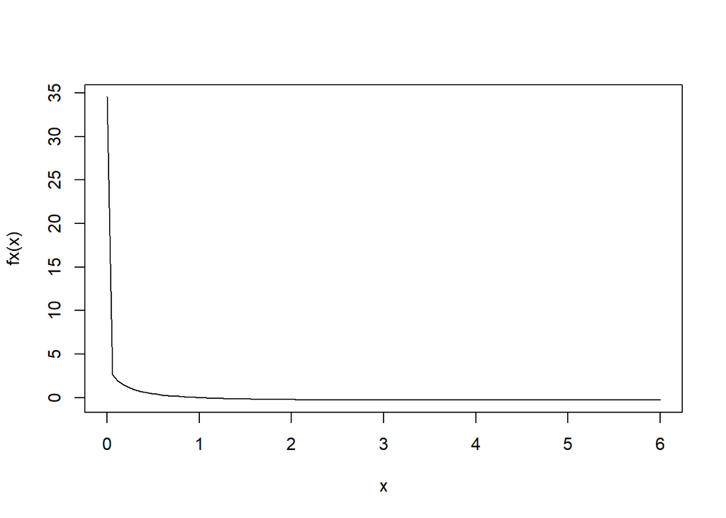

```r
curve(fx, from = 0.000000000000001, to = 6)
```

3. By inspection, were do you think global minimum is located at?

##### The global minimum is located at x = 3

4. Define a **R** function which computes the difference quotient of $f(x)$, i.e., for $h>0$,
   $$\frac{f(x+h)-f(x)}{h}.$$
   This function should have two inputs; $h$ and $x$. Name the difference quotient function **diff.quot**. Note that for small $h$, this function is the approximate derivative of $f(x)$.

```r
diff.quot = function(x,h){
  f = ((-log(x+h)/(1+x+h))+(log(x)/(1+x)))/h
  stopifnot(x > 0)
  return(f)
}
```

5. Plot both the difference quotient function **diff.quot** and $f(x)$ over the interval $(0,6]$. Fix $h=.0001$ to construct this plot. Comment on any interesting features.

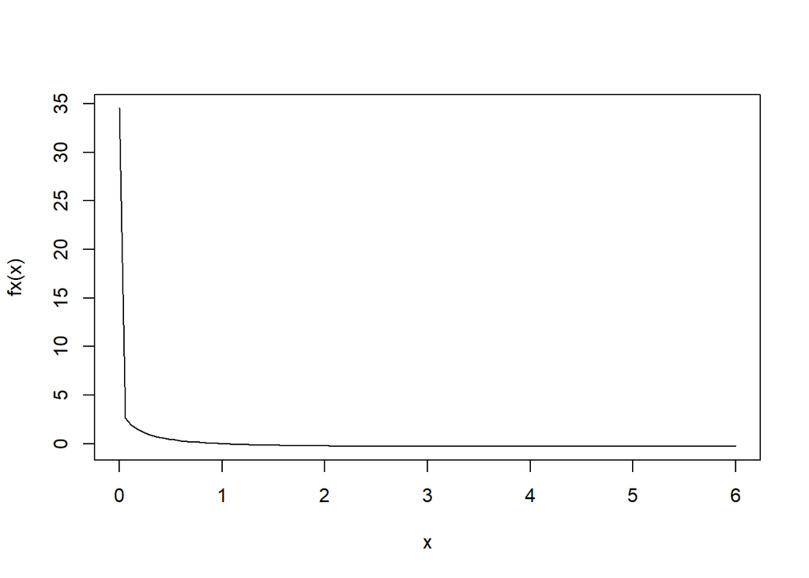

```r
curve(fx(x), from = 0.000000000000001, to = 6)
```

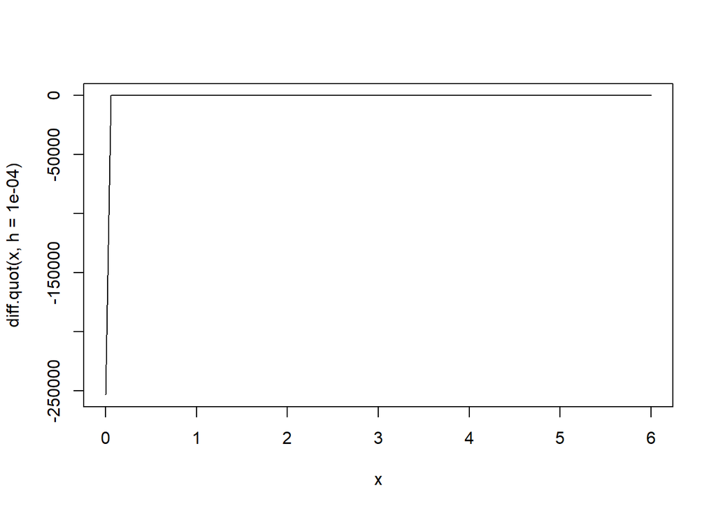

```r
curve(diff.quot(x,h=0.0001), from =0.000000000000001, to = 6)
```

##### The slopes of derivitive of this funtion and orignal funtion all sharp at the beginning but tend to be zero in the following part.

```r
basic.grad.descent = function(x, max.iter = 10000, stop.deriv = 1e-10, h = 0.0001, step.scale = 0.5){
  iter = 0
  derive = x
  div_step = h

  while((iter<max.iter) & (abs(derive)>stop.deriv)){
    iter = iter+1
    derive = derive - step.scale*diff.quot(x = derive, h=div_step)
    result = fx(derive)
    converge = iter < max.iter
  }
  return(list(derive, result, iter, converge))
}

basic.grad.descent(x = 5)
```

```
## [[1]]
## [1] 3.591071
##
## [[2]]
## [1] -0.2784645
##
## [[3]]
## [1] 10000
##
## [[4]]
## [1] FALSE
```

##### The x is 3.591071, the minimum is -0.2784645, the number of iterations is 10000, and the algorithm is not converged

7. Check the optimal value using the base **R** function **nlm()**.

```r
nlm(fx,2)
```

```
## $minimum
## [1] -0.2784645
##
## $estimate
## [1] 3.591117
##
## $gradient
## [1] -5.020728e-08
##
## $code
## [1] 1
##
## $iterations
## [1] 8
```

###### The optimal value is -0.2784645 at the point 3.591117. The result is almost the same with my own function.